# Projekt zaliczeniowy ze Statystycznej Analizy Danych, semestr letni 2025/2026

Alicja Rączka, 458933

2026-05-30

**Celem analizy jest zbadanie zależności pomiędzy warunkami pogodowymi a liczbą wypożyczeń rowerów oraz budowa modelu predykcyjnego umożliwiającego prognozowanie liczby wypożyczeń.**

# 1. Podstawowe informacje o danych

W pierwszej części raportu przeprowadzono wstępną analizę danych. Obejmuje ona sprawdzenie występowania brakujących wartości, analizę zmian temperatury oraz liczby wypożyczeń rowerów w czasie, a także badanie zależności pomiędzy zmiennymi meteorologicznymi za pomocą macierzy korelacji. Dodatkowo utworzono zmienną binarną `weekend`, która zostanie wykorzystana podczas budowy modeli predykcyjnych.

```r
library(tidyverse)
library(lubridate)
library(corrplot)
library(gridExtra)

bike <- read.csv("bike_train.csv")
bike <- bike %>%
  select(-X)

bike$date <- as.Date(bike$date)
```

## Brakujące wartości

W pierwszym kroku sprawdzono występowanie brakujących wartości w zbiorze danych.

```r
missing_values <- colSums(is.na(bike))
missing_values
```

```
##  date wcond  temp atemp   hum  wind count
##     0     0     0     0     0     0     0
```

W zbiorze danych nie stwierdzono brakujących wartości. Wszystkie zmienne posiadają komplet obserwacji, dlatego nie było konieczności stosowania metod imputacji ani usuwania rekordów.

## Temperatura i liczba wypożyczeń w zależności od dnia

Poniżej przedstawiono przebieg temperatury oraz liczby wypożyczonych rowerów w kolejnych dniach roku.

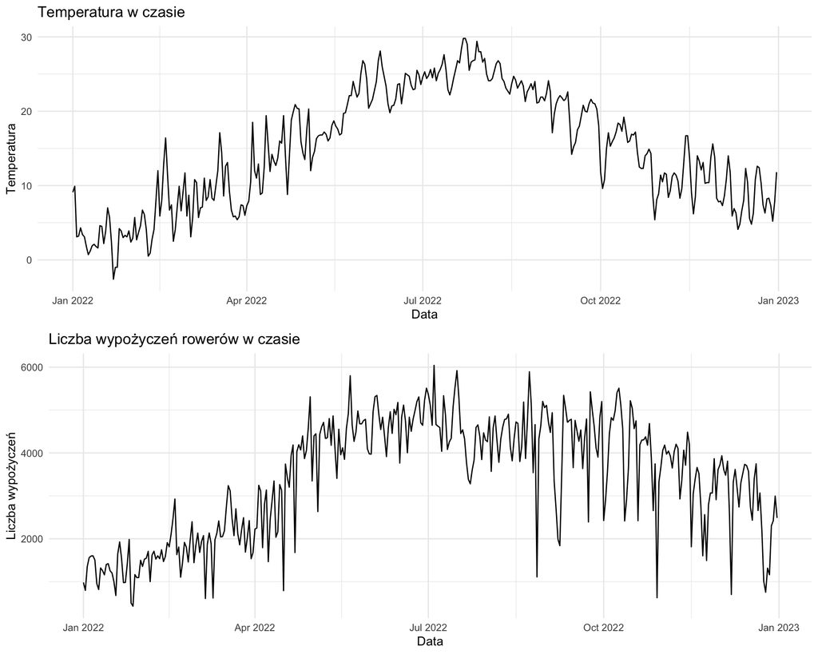

```r
p1 <- ggplot(bike, aes(x = date, y = temp)) +
  geom_line() +
  labs(title = "Temperatura w czasie", x = "Data", y = "Temperatura") +
  theme_minimal()

p2 <- ggplot(bike, aes(x = date, y = count)) +
  geom_line() +
  labs( title = "Liczba wypożyczeń rowerów w czasie", x = "Data", y = "Liczba wypożyczeń") +
  theme_minimal()

grid.arrange(p1, p2, ncol = 1)
```

Na wykresach można zaobserwować zmienność temperatury oraz liczby wypożyczeń rowerów w czasie. Widoczna jest sezonowość obu zmiennych, a większa liczba wypożyczeń występuje zwykle w okresach o wyższych temperaturach.

## Macierz korelacji zmiennych meteorologicznych

W celu zbadania zależności pomiędzy ilościowymi zmiennymi meteorologicznymi wyznaczono macierz korelacji Pearsona.

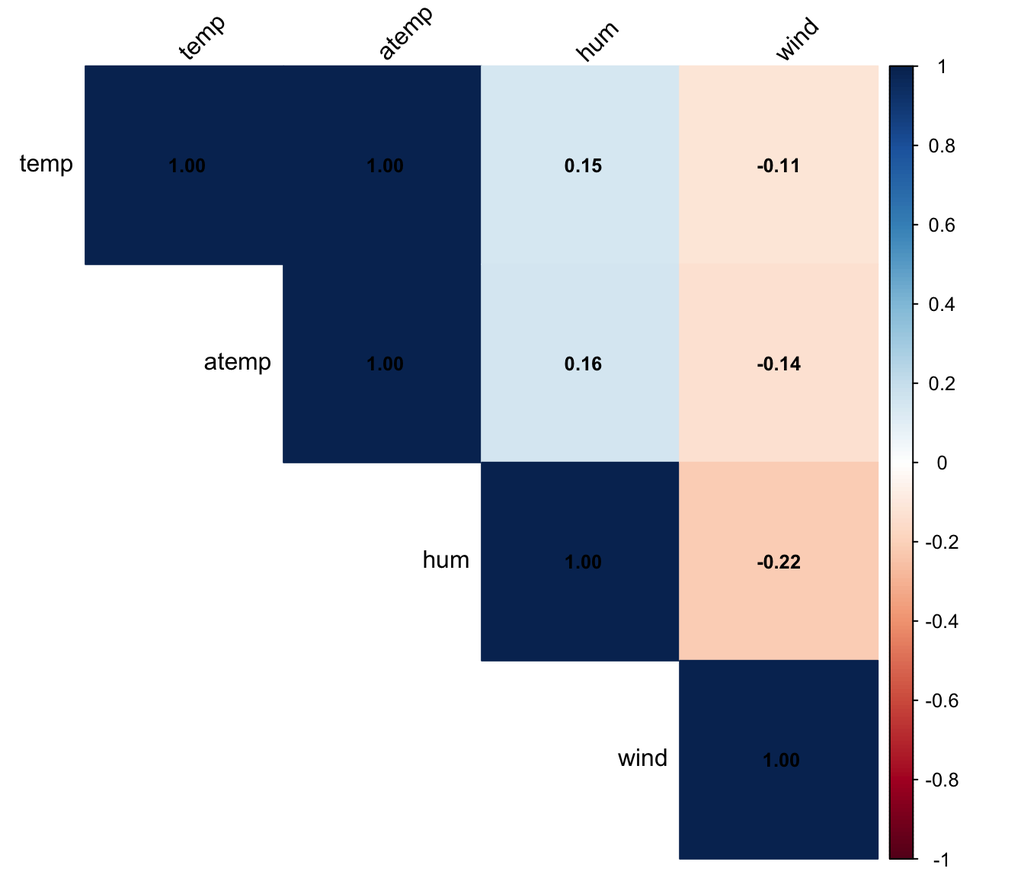

```r
weather_vars <- bike %>%
  select(temp, atemp, hum, wind)

corr_matrix <- cor(weather_vars)

corrplot(corr_matrix, method = "color", type = "upper", addCoef.col = "black", number.cex = 0.8, tl.col = "black", tl.srt = 45)
```

Mapa ciepła przedstawia siłę i kierunek zależności pomiędzy analizowanymi zmiennymi meteorologicznymi. Najsilniejszą zależność zaobserwowano pomiędzy zmiennymi `temp` oraz `atemp` (korelacja bliska 1), co oznacza, że temperatura rzeczywista i odczuwalna niosą bardzo podobną informację. Pozostałe zmienne wykazują jedynie słabe zależności liniowe – wilgotność jest nieznacznie dodatnio skorelowana z temperaturą, natomiast prędkość wiatru wykazuje słabą ujemną korelację zarówno z temperaturą, jak i wilgotnością.

Otrzymane wyniki sugerują, że poza parą zmiennych `temp`–`atemp` nie występuje silna współliniowość między analizowanymi cechami meteorologicznymi. Może to być korzystne podczas budowy modeli predykcyjnych, ponieważ większość zmiennych wnosi częściowo niezależną informację o warunkach pogodowych.

## Utworzenie zmiennej weekend

Na potrzeby dalszej analizy oraz budowy modeli predykcyjnych utworzono zmienną binarną `weekend`, przyjmującą wartość 1 dla sobót i niedziel oraz 0 dla pozostałych dni tygodnia.

```r
bike$weekend <- ifelse(wday(bike$date) %in% c(1, 7), 1, 0)

table(bike$weekend)
```

```
##
##   0   1
## 260 105
```

Nowa zmienna zostanie wykorzystana w dalszej części projektu podczas budowy modeli predykcyjnych.

# Analiza składowych głównych

W celu zbadania struktury danych meteorologicznych przeprowadzono analizę składowych głównych (PCA, Principal Component Analysis). Analizie poddano ilościowe zmienne opisujące warunki pogodowe: temperaturę (`temp`), temperaturę odczuwalną (`atemp`), wilgotność (`hum`) oraz prędkość wiatru (`wind`).

Ponieważ zmienne są wyrażone w różnych jednostkach, przed wykonaniem PCA zostały wystandaryzowane.

```r
weather_vars <- bike %>%
  select(temp, atemp, hum, wind)

pca_model <- prcomp(weather_vars, center = TRUE, scale. = TRUE)
```

## Wyjaśniona wariancja

W celu określenia liczby istotnych składowych głównych obliczono udział wyjaśnionej oraz skumulowanej wariancji.

```r
explained_var <- pca_model$sdev^2
explained_var_ratio <- explained_var / sum(explained_var)

cum_var <- cumsum(explained_var_ratio)

pca_table <- data.frame(Skladowa = paste0("PC", 1:length(explained_var)),
  Wyjasniona_wariancja = round(explained_var_ratio * 100, 2),
  Skumulowana_wariancja = round(cum_var * 100, 2)
)

pca_table
```

```
##   Skladowa Wyjasniona_wariancja Skumulowana_wariancja
## 1      PC1                52.12                 52.12
## 2      PC2                28.20                 80.32
## 3      PC3                19.59                 99.92
## 4      PC4                 0.08                100.00
```

## Skumulowana wariancja

Na poniższym wykresie przedstawiono skumulowany udział wyjaśnionej wariancji w zależności od liczby uwzględnionych składowych głównych.

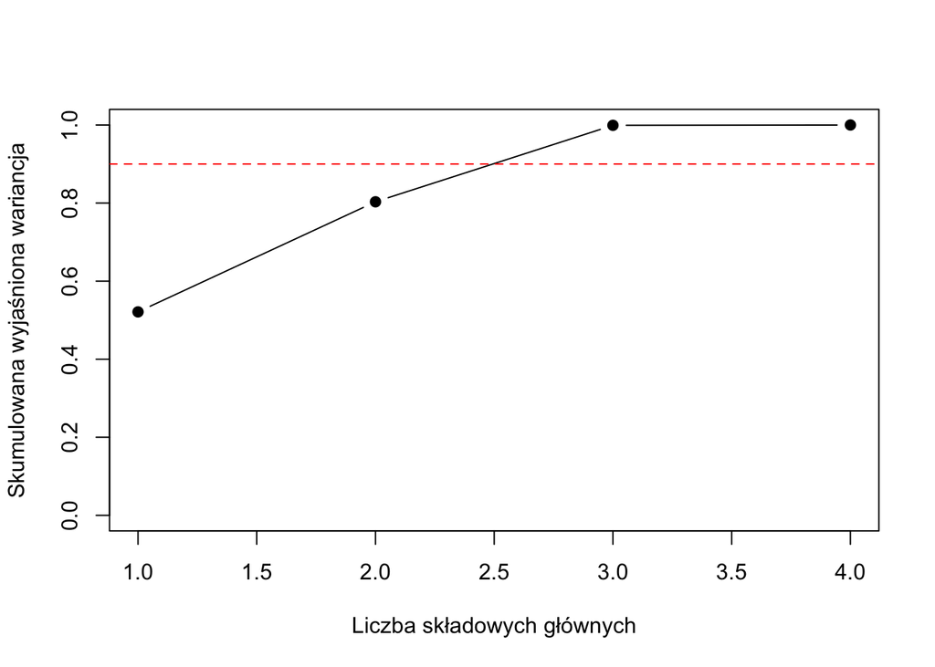

```r
plot(cum_var, type = "b", pch = 19, xlab = "Liczba składowych głównych", ylab = "Skumulowana wyjaśniona wariancja", ylim = c(0, 1))

abline(h = 0.9, col = "red", lty = 2)
```

## Liczba składowych odpowiadających za co najmniej 90% wariancji

```r
min_components <- which(cum_var >= 0.9)[1]
min_components
```

```
## [1] 3
```

Pierwsza składowa główna wyjaśnia **52,12%** całkowitej wariancji danych, natomiast dwie pierwsze składowe odpowiadają łącznie za **80,32%** wariancji. Po uwzględnieniu trzeciej składowej wyjaśnione zostaje już **99,92%** całkowitej wariancji.

Oznacza to, że najmniejsza liczba składowych głównych pozwalająca zachować co najmniej **90%** informacji zawartej w danych wynosi **3**.

Wysoki udział wariancji wyjaśnianej przez pierwsze składowe jest związany z bardzo silną korelacją pomiędzy temperaturą rzeczywistą (`temp`) oraz temperaturą odczuwalną (`atemp`), co zostało zaobserwowane wcześniej na macierzy korelacji. W praktyce oznacza to, że dane meteorologiczne mogą zostać zredukowane z czterech do trzech wymiarów przy minimalnej utracie informacji.

# 3. Model lasów losowych

W celu przewidywania liczby wypożyczonych rowerów wytrenowano model lasów losowych. Jako funkcję straty wykorzystano błąd średniokwadratowy (MSE).

## Dobór hiperparametrów przy użyciu 5-krotnej walidacji krzyżowej

Rozważono trzy hiperparametry modelu:

- `mtry` – liczba zmiennych losowanych przy każdym podziale,
- `min.node.size` – minimalna liczba obserwacji w liściu,
- `num.trees` – liczba drzew w lesie.

Przeszukiwana siatka obejmowała 125 konfiguracji hiperparametrów.

```r
library(caret)
library(ranger)
set.seed(123)

folds <- createFolds(bike$count, k = 5, returnTrain = FALSE)

grid <- expand.grid(
  mtry = c(2, 3, 4, 5, 6),
  min.node.size = c(1, 3, 5, 7, 9),
  num.trees = c(100, 300, 500, 700, 900)
)

results <- data.frame()

for(i in 1:nrow(grid))
{
  train_mse <- c()
  valid_mse <- c()

  params <- grid[i,]

  for(f in 1:length(folds))
  {
    test_idx <- folds[[f]]

    train_data <- bike[-test_idx,]
    test_data  <- bike[test_idx,]

    rf_model <- ranger(count ~ ., data = train_data, mtry = params$mtry, min.node.size = params$min.node.size, num.trees = params$num.trees, seed = 123)

    pred_train <- predict(rf_model, train_data)$predictions
    pred_test  <- predict(rf_model, test_data)$predictions

    train_mse <- c(train_mse, mean((train_data$count - pred_train)^2))

    valid_mse <- c(valid_mse,mean((test_data$count - pred_test)^2))
  }

  results <- rbind(results, data.frame(mtry = params$mtry,
                                      min.node.size = params$min.node.size,
                                      num.trees = params$num.trees,
                                      train_mse = mean(train_mse),
                                      valid_mse = mean(valid_mse)
                                      )
  )
}
```

Najlepszą konfigurację wyznaczono na podstawie najmniejszego średniego błędu walidacyjnego.

```r
best_idx <- which.min(results$valid_mse)

best_rf <- results[best_idx, ]

best_rf
```

```
##    mtry min.node.size num.trees train_mse valid_mse
## 29    5             1       300  35920.19  253625.5
```

Otrzymana tabela zawiera optymalne wartości hiperparametrów oraz odpowiadający im błąd walidacyjny. Spośród 125 analizowanych konfiguracji najmniejszy średni błąd walidacyjny uzyskano dla modelu o parametrach: `mtry = 5`, `min.node.size = 1` oraz `num.trees = 300`. Odpowiadający tej konfiguracji średni błąd walidacyjny wyniósł **253625,5**.

## Wykres błędu treningowego i walidacyjnego

Poniższy wykres przedstawia wszystkie analizowane konfiguracje hiperparametrów. Każdy punkt odpowiada jednej konfiguracji, natomiast współrzędne oznaczają średni błąd treningowy oraz średni błąd walidacyjny uzyskany w 5-krotnej walidacji krzyżowej.

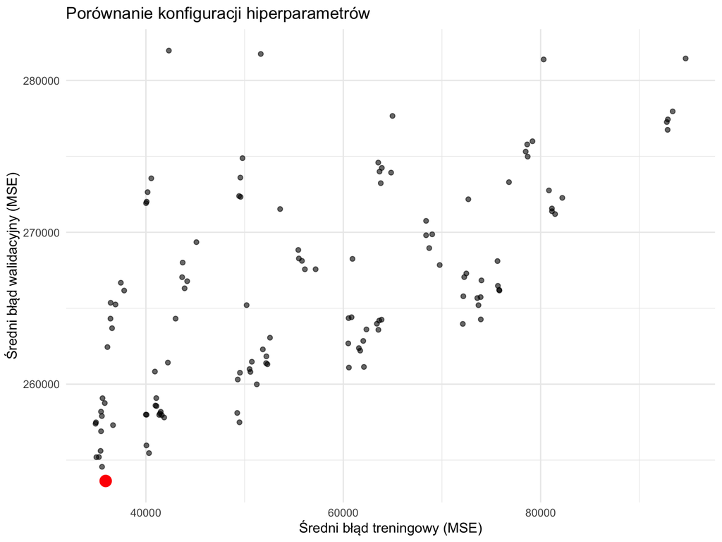

```r
library(ggplot2)

ggplot(results, aes(x = train_mse, y = valid_mse)) +
  geom_point(alpha = 0.6) +
  geom_point(data = best_rf, colour = "red", size = 4) +
  labs(x = "Średni błąd treningowy (MSE)", y = "Średni błąd walidacyjny (MSE)", title = "Porównanie konfiguracji hiperparametrów") +
  theme_minimal()
```

Na wykresie każda kropka reprezentuje jedną konfigurację hiperparametrów. Można zauważyć, że konfiguracje osiągające bardzo niski błąd treningowy nie zawsze charakteryzują się najniższym błędem walidacyjnym, co wskazuje na możliwość przeuczenia modelu. Najlepsza konfiguracja została oznaczona kolorem czerwonym. W dalszej części raportu model ten zostanie wykorzystany do porównania z regresją grzbietową.

# 4. Regresja grzbietowa

W celu porównania z modelem lasów losowych przeprowadzono regresję grzbietową (Ridge Regression). Jako funkcję straty wykorzystano błąd średniokwadratowy (MSE). Do walidacji modelu zastosowano te same 5 foldów, które wykorzystano wcześniej podczas strojenia modelu lasów losowych.

## Dobór parametru λ przy użyciu 5-krotnej walidacji krzyżowej

Rozważono 10 wartości parametru regularyzacji λ.

```r
library(glmnet)
lambda_grid <- 10^seq(-3, 3, length.out = 10)

lambda_grid
```

```
##  [1] 1.000000e-03 4.641589e-03 2.154435e-02 1.000000e-01 4.641589e-01
##  [6] 2.154435e+00 1.000000e+01 4.641589e+01 2.154435e+02 1.000000e+03
```

Ponieważ pakiet `glmnet` wymaga danych w postaci macierzy, przygotowano odpowiednie zmienne objaśniające.

```r
ridge_results <- data.frame()

for(lambda in lambda_grid)
{
  fold_mse <- c()

  for(f in 1:length(folds))
  {
    test_idx <- folds[[f]]

    train_data <- bike[-test_idx, ]
    test_data  <- bike[test_idx, ]

    X_train <- model.matrix(count ~ ., train_data)[, -1]
    y_train <- train_data$count

    X_test <- model.matrix(count ~ ., test_data)[, -1]
    y_test <- test_data$count

    ridge_model <- glmnet(X_train, y_train, alpha = 0, lambda = lambda, standardize = TRUE)

    pred <- predict(ridge_model, newx = X_test, s = lambda)

    mse <- mean((y_test - pred)^2)

    fold_mse <- c(fold_mse, mse)

    ridge_results <- rbind(ridge_results, data.frame(lambda = lambda, fold = f, mse = mse))
  }
}
```

Obliczono również średni błąd walidacyjny dla każdej wartości λ.

```r
ridge_summary <- aggregate(mse ~ lambda, data = ridge_results, mean)

colnames(ridge_summary)[2] <- "cv_mse"

ridge_summary
```

```
##          lambda   cv_mse
## 1  1.000000e-03 552932.0
## 2  4.641589e-03 552924.0
## 3  2.154435e-02 552899.2
## 4  1.000000e-01 552777.5
## 5  4.641589e-01 552284.4
## 6  2.154435e+00 550816.5
## 7  1.000000e+01 549111.9
## 8  4.641589e+01 547336.8
## 9  2.154435e+02 549785.3
## 10 1.000000e+03 627816.3
```

## Wpływ parametru λ na błąd walidacyjny

Na poniższym wykresie przedstawiono błędy średniokwadratowe uzyskane w poszczególnych foldach dla każdej wartości parametru λ. Czerwone punkty oznaczają średni błąd walidacyjny uzyskany w 5-krotnej walidacji krzyżowej.

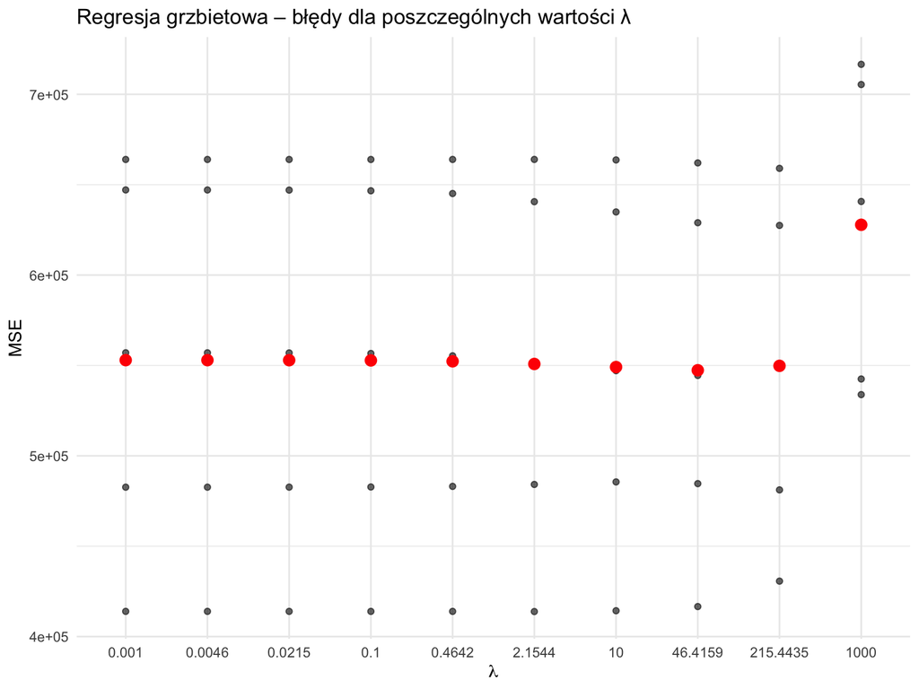

```r
library(ggplot2)

ggplot(ridge_results, aes(x = factor(round(lambda, 4)), y = mse)) +
  geom_point(alpha = 0.6) +
  geom_point(data = ridge_summary, aes(x = factor(round(lambda, 4)), y = cv_mse), colour = "red", size = 3) +
  labs(x = expression(lambda), y = "MSE", title = "Regresja grzbietowa – błędy dla poszczególnych wartości λ") +
  theme_minimal()
```

## Wybór najlepszego λ

```r
best_ridge <- ridge_summary[which.min(ridge_summary$cv_mse),]

best_ridge
```

```
##     lambda   cv_mse
## 8 46.41589 547336.8
```

Najlepszą wartość parametru λ wybrano na podstawie najmniejszego średniego błędu walidacyjnego.

```r
rf_best_mse <- min(results$valid_mse)

comparison <- data.frame(Model = c("Random Forest", "Ridge"),Validation_MSE = c(rf_best_mse, best_ridge$cv_mse))

comparison
```

```
##           Model Validation_MSE
## 1 Random Forest       253625.5
## 2         Ridge       547336.8
```

Najmniejszy średni błąd walidacyjny w regresji grzbietowej uzyskano dla wartości parametru regularyzacji **λ = 46,42**. Odpowiadający tej wartości średni błąd walidacyjny wyniósł **547336,8**.

Porównując uzyskany wynik z najlepszym modelem lasów losowych, można zauważyć znaczącą różnicę jakości predykcji. Najlepszy model lasów losowych osiągnął średni błąd walidacyjny równy **253625,5**, podczas gdy dla regresji grzbietowej było to **547336,8**.

Oznacza to, że w analizowanym problemie model lasów losowych zapewnia zdecydowanie lepszą jakość predykcji liczby wypożyczeń rowerów niż regresja grzbietowa. Może to sugerować występowanie nieliniowych zależności pomiędzy zmiennymi meteorologicznymi a liczbą wypożyczeń, które są lepiej odwzorowywane przez lasy losowe niż przez model liniowy z regularyzacją.

# 5. Porównanie modeli

W celu porównania jakości predykcji zestawiono wyniki uzyskane przez trzy modele:

- model referencyjny (Baseline),
- regresję grzbietową (Ridge Regression),
- lasy losowe (Random Forest).

Model referencyjny przypisuje wszystkim obserwacjom w zbiorze testowym średnią wartość zmiennej `count` obliczoną na danych treningowych.

## Model referencyjny

```r
baseline_mse <- c()

for(f in 1:length(folds))
{
  test_idx <- folds[[f]]

  train_data <- bike[-test_idx, ]
  test_data  <- bike[test_idx, ]

  mean_count <- mean(train_data$count)

  pred <- rep(mean_count, nrow(test_data))

  mse <- mean((test_data$count - pred)^2)

  baseline_mse <- c(baseline_mse, mse)
}

baseline_cv_mse <- mean(baseline_mse)

baseline_cv_mse
```

```
## [1] 1897119
```

## Tabela porównawcza

```r
comparison_table <- data.frame(Model = c("Baseline", "Ridge", "Random Forest"), CV_MSE = c(baseline_cv_mse, best_ridge$cv_mse, rf_best_mse))

comparison_table <- comparison_table[order(comparison_table$CV_MSE),]

comparison_table
```

```
##           Model    CV_MSE
## 3 Random Forest  253625.5
## 2         Ridge  547336.8
## 1      Baseline 1897119.3
```

## Interpretacja wyników

Na podstawie przeprowadzonej 5-krotnej walidacji krzyżowej porównano trzy modele predykcyjne: model referencyjny (Baseline), regresję grzbietową (Ridge) oraz lasy losowe (Random Forest).

Największy błąd uzyskał model referencyjny, dla którego średni błąd walidacyjny wyniósł **1897119,3**. Oznacza to, że sama średnia liczby wypożyczeń jest bardzo słabym predyktorem analizowanego zjawiska.

Regresja grzbietowa znacząco poprawiła jakość predykcji, osiągając średni błąd walidacyjny równy **547336,8**. Wskazuje to, że zmienne meteorologiczne oraz kalendarzowe zawierają istotną informację pozwalającą przewidywać liczbę wypożyczeń rowerów.

Najlepsze wyniki uzyskał model lasów losowych, dla którego średni błąd walidacyjny wyniósł jedynie **253625,5**. Jest to wynik ponad dwukrotnie lepszy od regresji grzbietowej i ponad siedmiokrotnie lepszy od modelu referencyjnego.

Na podstawie przeprowadzonego porównania można stwierdzić, że model lasów losowych najlepiej opisuje zależność pomiędzy warunkami pogodowymi a liczbą wypożyczeń rowerów. W dalszych analizach i predykcjach najbardziej uzasadnione jest wykorzystanie właśnie tego modelu.

# Wnioski końcowe

Przeprowadzona analiza wykazała, że warunki pogodowe są istotnie związane z liczbą wypożyczeń rowerów. Spośród analizowanych modeli najlepsze wyniki uzyskał model lasów losowych, osiągając najniższy błąd walidacyjny (**253625,5**). Regresja grzbietowa poprawiała jakość predykcji względem modelu referencyjnego, jednak była wyraźnie słabsza od lasów losowych.